# Ford Go Bike System Data

## by Sumeet Sawant

## Preliminary Wrangling

This data set includes information about individual rides made in a bike-sharing system covering the greater San Francisco Bay area.

My aim here is to see how the ride duration in seconds is related or affected by other variables in the dataset

Describing the dataset .

I see that there are 2383421 rows and 16 columns the columns namly descibe

**bike id:** Unique id given to each bike  
**duration-sec :** Time of each ride  
**End station id and start station id :** Unique id given to each station  
**end_station_latitude and end_station_longtitude :** latitude and longitude of each end station  
**start_station_latitude and start_station_latitude:** latitude and longitude of each start station  
**end_station_name:** Name of each end station  
**start_station_name:** Name of each start station  
**start_time:** Date and Time when ride started  
**end_time:** Date and Time when ride ended  
**user_type:** Customer has yearly pass and subscriber has a day pass or 3 day pass  
**memeber_gender:** Gender identified by each user  
**member_birth_year:** Year of birth for each user  
**bike_share_for_all_trips:** To share bike info with the service provider

My main aim in this project is to see how the time-duration of the trip varies with other variables provided in the dataset as the time of the trip is directly proportional to the fare earned

### Structure of the dataset

2383421 rows and 16 columns

### The main feature of interest in the dataset

'duration_sec'

### Variables I feel will affect the main feature of interest

'duration_sec', 'end_station_name','end_time', 'member_birth_year', 'member_gender', 'start_station_name', 'start_time', 'user_type'

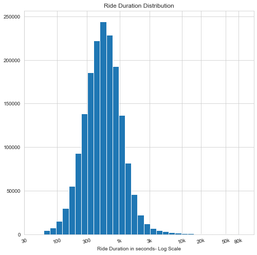

```python
plt.figure(figsize=(11.69,8.27));
bin_range=10**np.arange(np.log10(bike_share_2018['duration_sec'].min()),np.log10(bike_share_2018['duration_sec'].max())+0.1,0.1)
plt.figure(figsize=(8,8))
plt.hist(x=bike_share_2018['duration_sec'],bins=bin_range);
plt.xscale('log')
labels=[30,100,300,1000,3000,10000,20000,50000,80000]
marks=[30,100,300,'1k','3k','10k','20k','50k','80k'];
plt.xticks(labels,marks,rotation=15);
plt.xlabel('Ride Duration in seconds- Log Scale');
plt.title('Ride Duration Distribution');
```

We see how our variable of interest is distributed in the graph above. The graph is made by using the log scale on X axis  
We see almost all the rides lasting less than 10,000 secs with majority of rides less than 3000 secs

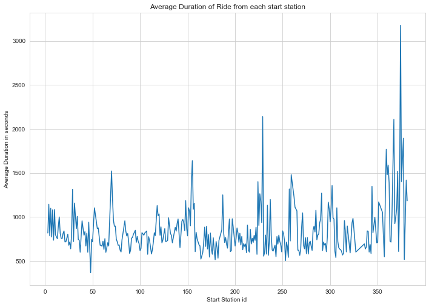

```python
plt.figure(figsize=(11.69,8.27));
plt.errorbar(x=mean_start_time['start_station_id'],y=mean_start_time['duration_sec']);
plt.title('Average Duration of Ride from each start station');
plt.xlabel('Start Station id ');
plt.ylabel('Average Duration in seconds');
```

The above graph indicates what is the average duration of ride from each start station . We see that station above 350 seem to have a higher ride time average . That means station above 350 are either located far from downtown or most points of interest . This would be a good area to focus as station having ride duration can give bigger revenue

The company must make sure that enough bikes are always avaliable at this station and if possible people from this station take round trip by which we can also increase ride times more

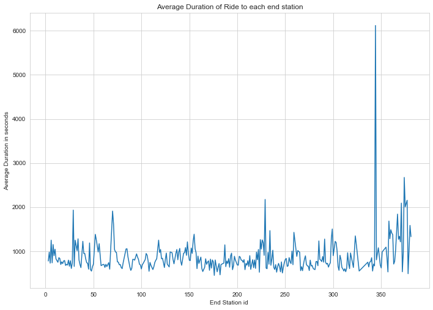

```python
plt.figure(figsize=(11.69,8.27));
plt.errorbar(x=mean_end_time['end_station_id'],y=mean_end_time['duration_sec']);
plt.title('Average Duration of Ride to each end station');
plt.xlabel('End Station id ');
plt.ylabel('Average Duration in seconds');
```

The above graph indicates what is the average duration of ride to each end station . We see that station above 350 seem to have a higher ride time average . There is also one location which has a substantial higher average than other . Upon futher investigation of the higher outlier point I feel that rides ending to that station are indeed of higher time . We there must make sure customers travelling to station id 344 get preferance in bike selection over shorter rides to increase revnue if bike numbers are limited by giving ride reservation capability to customers travelling towards those higher end time destinations

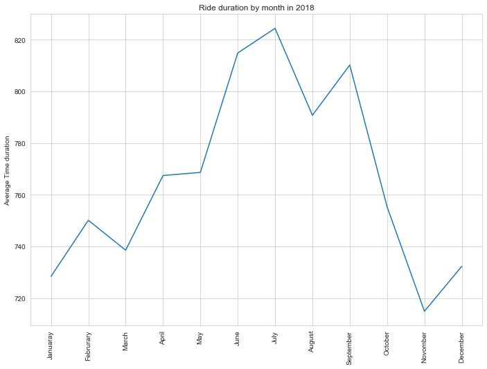

```python
plt.figure(figsize=(11.69,8.27));
plt.errorbar(x=ride_duration_by_month['start_month'],y=ride_duration_by_month['duration_sec']);
plt.title('Ride duration by month in 2018');
#plt.xlabel('Month');
plt.ylabel('Average Time duration');
loc=[1,2,3,4,5,6,7,8,9,10,11,12]
labels=['Januaray','Februrary','March','April','May',"June",'July','August','September','October','Novomber','December']
plt.xticks(loc,labels,rotation=90);
```

We see that the rides average duration through spring reaching a max in summer in July and decreasing as winter months approach

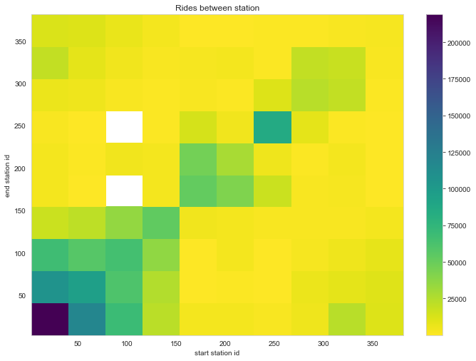

```python
plt.figure(figsize=(11.69,8.27));
plt.hist2d(x=bike_share_2018['start_station_id'],y=bike_share_2018['end_station_id'],cmin=0.5,cmap='viridis_r');
plt.colorbar();
plt.xlabel('start station id');
plt.ylabel('end station id');
plt.title("Rides between station");
```

we see that most rides occour between ids of (0-120 ). Commute between this station ids generates a major revenue for the company and hence this routes should be taken care of .